# USA Retail Trade Analysis

# 1. Introduction

Retail sales is the purchases of finished goods and services by consumers and businesses. These goods and services have made it to the end of the supply chain. The chain starts with the goods producer or provider and ends with the retailer. The U.S. Census Bureau measures retail sales with the monthly U.S. retail sales report.It reveals total sales, percentage change, and change in year-over-year sales.

# 2. Exploratory Data Analysis

These two charts show retail sales without seasonal adjustments and seasonally adjusted, respectively.

Retail sales

```
##    Min. 1st Qu.  Median    Mean 3rd Qu.    Max.
##   146.4   249.9   335.9   334.3   414.3   591.4
```

Retail sales Adjusted

```
##    Min. 1st Qu.  Median    Mean 3rd Qu.    Max.
##   163.7   248.9   340.2   334.5   412.7   529.6
```

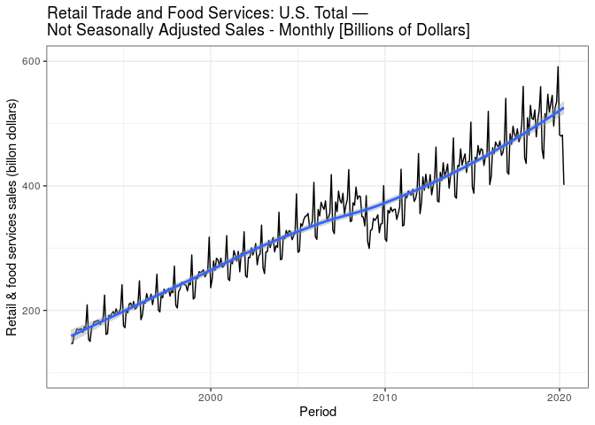

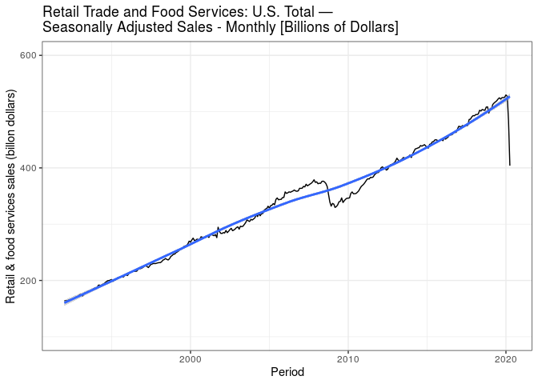

Spectrum Analysis to compare Non Seasonally Adjusted Sales and Seasonally Adjusted Sales

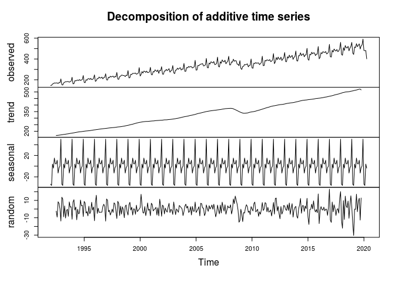

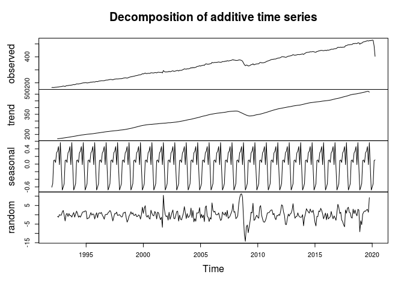

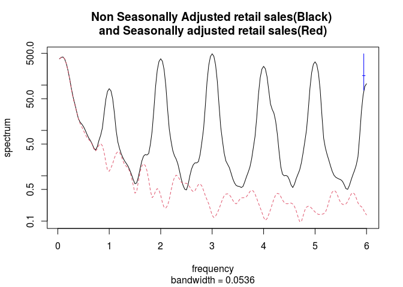

- The x-axis units are cycles per year.
- As shown by the spectrum frequncy plot, the seasonally adjusted retail sales removes most of the signal at seasonal frequencies.

The ratio of the periodograms of the smoothed and unsmoothed time series is called the transfer function or frequency response function of the smoother.

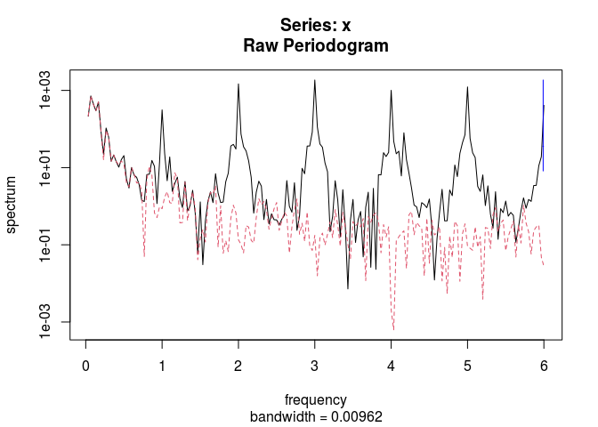

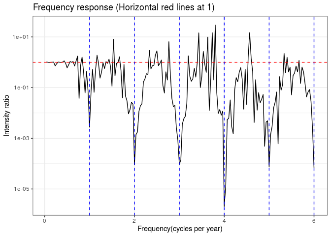

We can see from the spectrum plots, the raw retail sales data contains information of various frequencies, which makes it hard to examine the particular aspects of interest.

Therefore, I decompose the retail sales into three parts:

- low frequency trend
- high frequency noise
- middle frequency long-term cycles

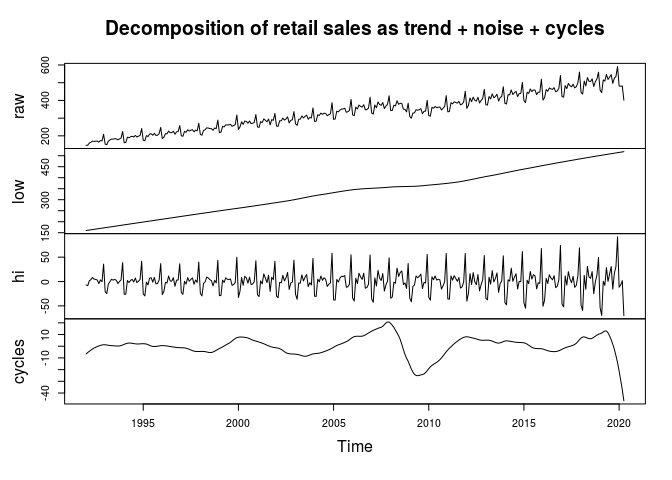

```
## [1] "Increase Rate:  12.7950823980658"
```

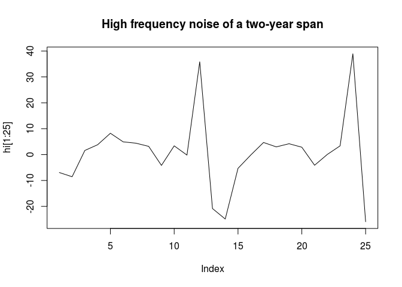

Fomr the above plot we can draw following conclusions

- The low frequency plot shows us an estimate of the trend followed by the sales from 1992 to 2020. The average increase rate is 12.7950824 billion dollars per year
- The high freguency plot shows us th seasonal changes in Retail sales. When I zoom into high frequency we see a sales peak in December and also at around May and June and this pattern occurs over every year. The seasonal change have a period of one year
- The middle frequency plot tells us about any long term changes is their is any. I can see that their is a steady increase from 2004 to 2008, but from around 2nd quater of 2008 retail sales begin to decline and it is not until last quater of 2009 it began to climb back. This shows the stock market crash on Sept. 29, 2008.The decline in Retail Sales partly reflects the economic downturn The same is happnning in the 1st quater of 2020 due to COVID-19 outbreak which is still going on. The decline in Retail Sales shows people refain from spending and shows the lockdown situation of the country

# 3 MODELING

From EDA we see both trend and seasonality in data

we can see a seasonal period of 12 on the retail sales data. A SARMA model with period equal to 12 can be used.

## 3.1 DEtrending the Data

```
##
## Call:
## lm(formula = `Retail sales ad` ~ Period, data = data_ad)
##
## Residuals:
##      Min       1Q   Median       3Q      Max
## -102.022   -3.841   -0.072    7.768   26.691
##
## Coefficients:
##               Estimate Std. Error t value Pr(>|t|)
## (Intercept) -1.041e+02  3.599e+00  -28.93   <2e-16 ***
## Period       3.324e-02  2.661e-04  124.94   <2e-16 ***
## ---
## Signif. codes:  0 '***' 0.001 '**' 0.01 '*' 0.05 '.' 0.1 ' ' 1
##
## Residual standard error: 14.66 on 338 degrees of freedom
## Multiple R-squared:  0.9788, Adjusted R-squared:  0.9787
## F-statistic: 1.561e+04 on 1 and 338 DF,  p-value: < 2.2e-16
```

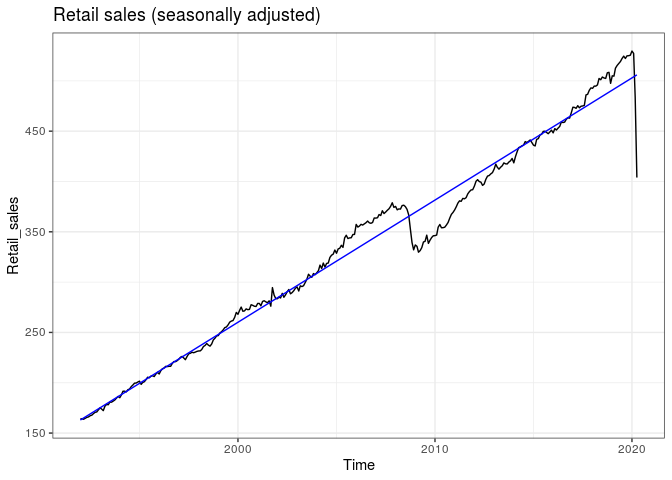

The linear fit looks good except for the severe economic crisis around 2008 and the latest COVID-19 outbreak

## 3.2 SARMA MODEL

In order to pick up the orders p and q, I calculate the AIC’s for SARMA(p,q)$\times(1,0)_{12}$.

### 3.2.1 SARMA(p,q)$\times(1,0)_{12}$ model

[output not shown]

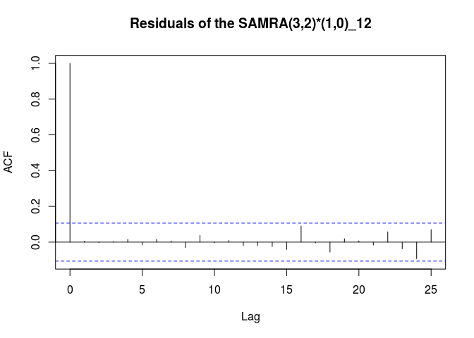

```
##
## Call:
## arima(x = new$detrend, order = c(3, 0, 2), seasonal = list(order = c(1, 0, 0),
##     period = 12), method = "ML")
##
## Coefficients:
##          ar1     ar2      ar3     ma1     ma2     sar1  intercept
##       0.9897  0.4866  -0.5458  0.6549  0.0129  -0.1483    -4.9288
## s.e.  0.2743  0.4667   0.2593  0.2680  0.1466   0.0740     6.1461
##
## sigma^2 estimated as 26.3:  log likelihood = -1040.72,  aic = 2097.45
```

### 3.2.2 SARMA(p,q)$\times (1,1)_{12}$ model

[output not shown]

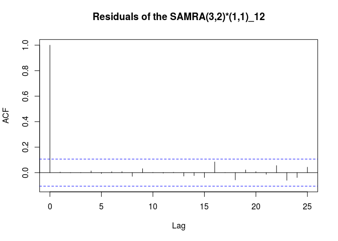

```
##
## Call:
## arima(x = new$detrend, order = c(3, 0, 2), seasonal = list(order = c(1, 0, 1),
##     period = 12), method = "ML")
##
## Coefficients:
##          ar1     ar2      ar3     ma1     ma2    sar1     sma1  intercept
##       1.0243  0.4255  -0.5164  0.6260  0.0241  0.4443  -0.6487    -4.1802
## s.e.  0.3269  0.5832   0.3129  0.3208  0.1534  0.1946   0.1615     4.7443
##
## sigma^2 estimated as 25.82:  log likelihood = -1038.04,  aic = 2094.07
```

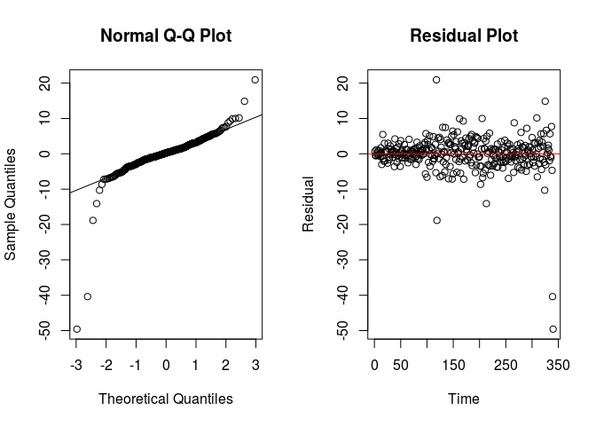

- The QQ plot shows only some points at the end deviate from the main line other than that the main line follows normal distribution.
- From the residual plot:-
  1. we can see there are a few influential points at position 200 and 300.
  2. outliers at position 120 & 350.
  3. some heteroscedasticity.

## 3.3 SARMA model on the log transformed data

since trend doesn’t change through the log transformation we can transform the the above linear model.

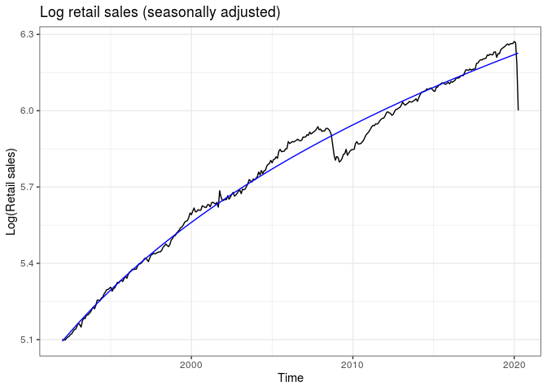

### 3.3.1 SARMA(p,q)$\times(1,0)_{12}$

[output not shown]

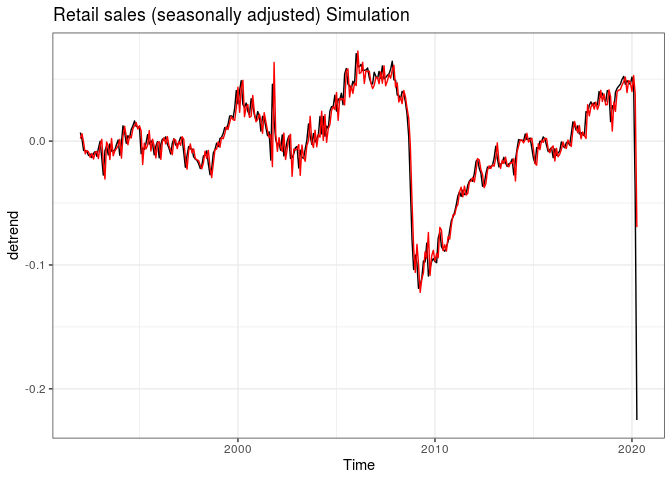

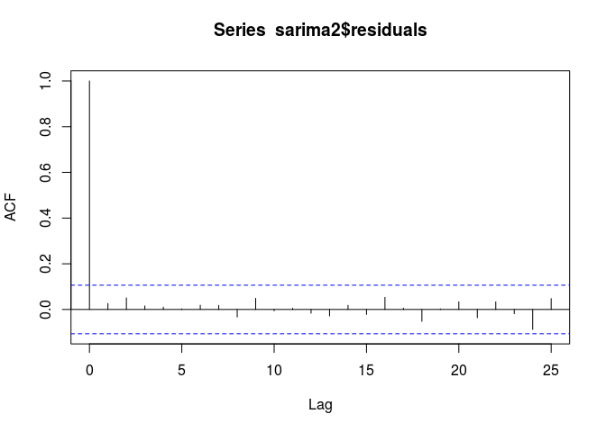

```
##
## Call:
## arima(x = new_log$detrend, order = c(2, 0, 2), seasonal = list(order = c(1,
##     0, 0), period = 12), method = "ML")
##
## Coefficients:
##          ar1     ar2     ma1     ma2     sar1  intercept
##       0.1838  0.7382  1.0881  0.2960  -0.1554    -0.0138
## s.e.  0.2848  0.2813  0.2508  0.0628   0.0775     0.0197
##
## sigma^2 estimated as 0.0001873:  log likelihood = 974.97,  aic = -1935.93
```

### 3.3.2 SARMA(p,q)$\times(1,1)_{12}$ model

|  | MA0 | MA1 | MA2 | MA3 |
| --- | --- | --- | --- | --- |
| AR0 | -1378.56 | -1630.56 | -1763.00 | -1821.01 |
| AR1 | -1920.89 | -1939.52 | -1942.97 | -1941.14 |
| AR2 | -1944.77 | -1944.17 | -1942.25 | -1941.33 |
| AR3 | -1944.09 | -1942.60 | -1940.95 | -1939.85 |

```
##
## Call:
## arima(x = new_log$detrend, order = c(2, 0, 2), seasonal = list(order = c(1,
##     0, 1), period = 12))
##
## Coefficients:
##          ar1      ar2      ma1      ma2    sar1     sma1  intercept
##       1.6990  -0.7227  -0.3566  -0.0444  0.4515  -0.6512    -0.0103
## s.e.  0.3697   0.3521   0.3912   0.1658  0.2181   0.1839     0.0125
##
## sigma^2 estimated as 0.0001822:  log likelihood = 979.12,  aic = -1942.25
```

comparing with the model fitted on non transformed data the standard error has significantly decreased

The ACF doesn’t show significant autocorrelation among residuals.

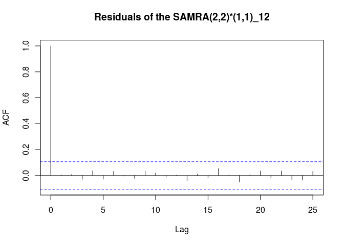

The red cure if from the model SARMA(p,q)$\times (1,1)_{12}$, which is very comparable to the original data which is shown by black line

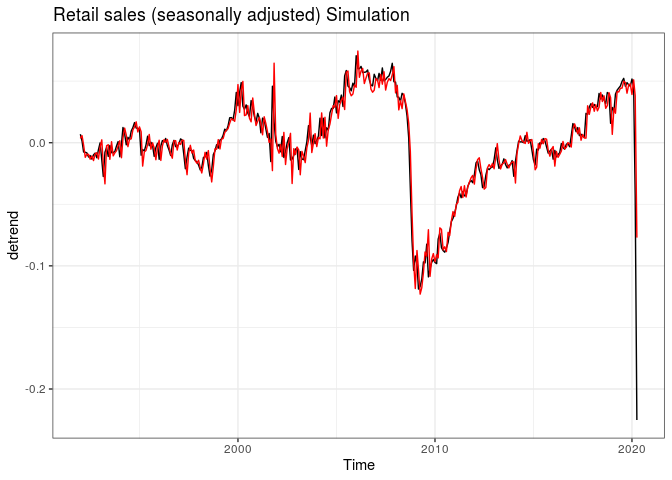

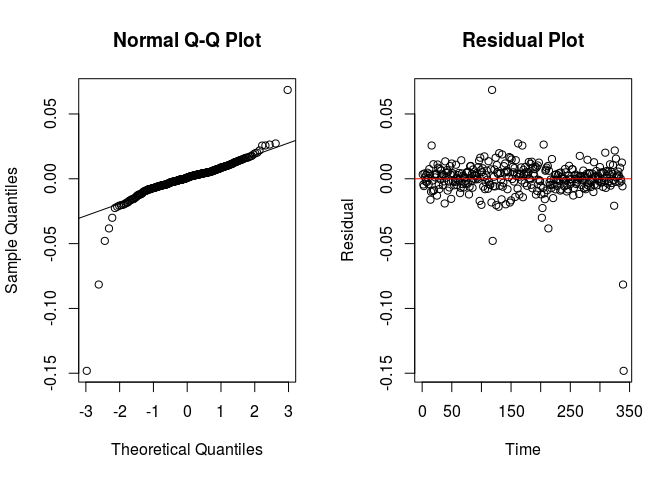